# CEO-REQUEST CHALLENGE

> Should Olist remove underperforming sellers from its marketplace?

**Olist would be more profitable if underperforming sellers had not joined Olist**

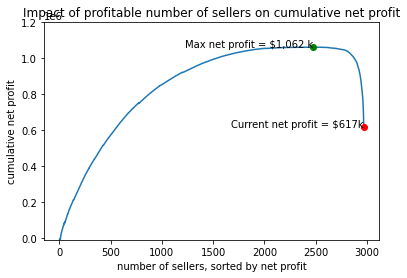

If only the top 2475 sellers remained with Olist, the company's net profit to date would be \$1,062 k, much higher than the current net profit of \$617 k.

It is therefore recommended that Olist look at ways of identifying and removing underperforming sellers.

**Method**

To get to this conclusion, the number of sellers were sorted by profit. The cumulative IT costs were then factored in determine the cumulative net profit. The table below shows the top 5 sellers.

|  | seller_id | profits | cum_sum_profit | cum_orders | IT_costs | net_profit |
| --- | --- | --- | --- | --- | --- | --- |
| 0 | 53243585a1d6dc2643021fd1853d8905 | 17967.605 | 17967.605 | 358 | 30000.519572 | -12032.914572 |
| 1 | 7e93a43ef30c4f03f38b393420bc753a | 14523.187 | 32490.792 | 694 | 41770.242648 | -9279.450648 |
| 2 | fa1c13f2614d7b5c4749cbc52fecda94 | 14254.203 | 46744.995 | 1279 | 56705.154120 | -9960.159120 |
| 3 | edb1ef5e36e0c8cd84eb3c9b003e486d | 7288.455 | 54033.450 | 1445 | 60272.774905 | -6239.324905 |
| 4 | ccc4bbb5f32a6ab2b7066a4130f114e3 | 6700.462 | 60733.912 | 1632 | 64054.159978 | -3320.247978 |

**Note: Underperformance still needs to be clearly defined**

This analysis shows that at a high level, it would be financially beneficial for Olist to remove underperforming sellers. The detailed outcome of this analysis should be treated with caution...

The graph below is a zoomed in version of the graph on the previous slide. The red line represents the 2475th top ranked seller.

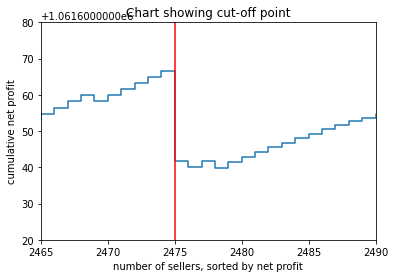

If we would take the red line as a 'cut off point', we would unnecessarily remove profitable sellers from Olist.